# chapter3

Jukke Kaaronen

09/11/2020

# Chapter 3 Logistic Regression

*This week I learned something about logistic regression and data wrangling to join datasets with common features. Again, the most frustrating part was trying to understand how to interpret statistics. There is still a lot to learn.*

## Library

```r
library(tidyverse)
```

## 1 Dataset and Description

### 1.1 Read Dataset from Local Directory

```r
alc <- read.csv("C:/Users/Jukke/OneDrive/Työpöytä/IODS/IODS-project/data/alc.csv")
```

### 1.2 Description

The original datasets used for this chapter are made by Paulo Cortez.  
Link to [metadata](https://archive.ics.uci.edu/ml/datasets/Student+Performance)  
**Database citation**:  
P. Cortez and A. Silva. Using Data Mining to Predict Secondary School Student Performance. In A. Brito and J. Teixeira Eds., Proceedings of 5th FUture BUsiness TEChnology Conference (FUBUTEC 2008) pp. 5-12, Porto, Portugal, April, 2008, EUROSIS, ISBN 978-9077381-39-7.  
**Original Dataset information**: Datasets of student achievement in secondary education in maths and Portuguese in two Portuguese schools with grades and social attributes. Original datasets contains 30 social attributes and 3 grade attributes (first period, second periond, and final grade).

### 1.3 Derived dataset

The dataset discussed in this report is derived from the original dataset, discussed in the previous section, by joining the math and Portuguese datasets. Observations with matching social attributes (same student) were selected from the datasets and their scores were averaged. Additional columns for alcohol use (alc_use) and high use (high_use) were created by averaging scores for weekday and weekend alcohol use, and high quantities thereof respectively.

```r
glimpse(alc)
```

```
## Rows: 382
## Columns: 35
## $ school     <chr> "GP", "GP", "GP", "GP", "GP", "GP", "GP", "GP", "GP", "G...
## $ sex        <chr> "F", "F", "F", "F", "F", "M", "M", "F", "M", "M", "F", "...
## $ age        <int> 18, 17, 15, 15, 16, 16, 16, 17, 15, 15, 15, 15, 15, 15, ...
## $ address    <chr> "U", "U", "U", "U", "U", "U", "U", "U", "U", "U", "U", "...
## $ famsize    <chr> "GT3", "GT3", "LE3", "GT3", "GT3", "LE3", "LE3", "GT3", ...
## $ Pstatus    <chr> "A", "T", "T", "T", "T", "T", "T", "A", "A", "T", "T", "...
## $ Medu       <int> 4, 1, 1, 4, 3, 4, 2, 4, 3, 3, 4, 2, 4, 4, 2, 4, 4, 3, 3,...
## $ Fedu       <int> 4, 1, 1, 2, 3, 3, 2, 4, 2, 4, 4, 1, 4, 3, 2, 4, 4, 3, 2,...
## $ Mjob       <chr> "at_home", "at_home", "at_home", "health", "other", "ser...
## $ Fjob       <chr> "teacher", "other", "other", "services", "other", "other...
## $ reason     <chr> "course", "course", "other", "home", "home", "reputation...
## $ nursery    <chr> "yes", "no", "yes", "yes", "yes", "yes", "yes", "yes", "...
## $ internet   <chr> "no", "yes", "yes", "yes", "no", "yes", "yes", "no", "ye...
```

[output cut: 22 more lines]

The dataset contains 382 observations (students) of 35 variables, see [metadata](https://archive.ics.uci.edu/ml/datasets/Student+Performance) for description. In addition, alc_use is `(Dalc + Walc) / 2` and high_use is logical TRUE/FALSE where `alc_use > 2`

## 2 Exploring Alcohol Use and Other Variables

The purpose of this chapter is to study the relation of high/low alchol use with other variables from the dataset.

### 2.3 Variables

I have chosen 4 variables of interest: sex, failures, famrel, and G3.  
**Sex**: Binary M/F  
*Hypothesis*: Sex will not correlate with use of alcohol  
**Failures**: Number of past class failures  
*Hypothesis*: Intuitively, failures might have correlations with alcohol use if alcohol use is an indicator of other social problems as well.  
**Famrel**: Quality of family relationships (numeric: from 1 - very bad to 5 - excellent)  
*Hypothesis*: Same as above, bad family relations might correlate with higher alcohol use.  
**G3**: Final Grade (average of math and Portuguese), numeric: from 0 to 20  
*Hypothesis*: Alcohol use and final grade may correlate.

### 2.3 Variable counts

There are 114 observations of High Alcohol Use, and 268 observations of non-high use:

```r
high_use <- alc %>% count(high_use)
high_use
```

```
##   high_use   n
## 1    FALSE 268
## 2     TRUE 114
```

#### 2.3.1 Sex and Alcohol Use

High use is distributed unequally between M (72/184)and F(42/198). First I check the possible values of sex with `distinct` to make sure nothing strange is in the dataset. I change the sex column into `factor` (not sure if necessary) check that it has worked with `str` and then proceed to `ggplot` with `geombar`. From this we see a differential distribution of alcohol use with regards to sex. This can also be seen in numbers with `xtabs`. A simple logistic regression with the generalised linear model `glm`, attributed with the argument `family = "binomial"`, which makes the function perform logistic regression, reveals a statistically significant relation with high alcohol use and sex in the dataset. The log(odds) for a female having high alcohol use (AU) is -1.3122 and the increase in log(odds) to a male having high AU is 0.8704. My intuitive hypothesis was wrong.

```r
distinct(alc, sex)
```

```
##   sex
## 1   F
## 2   M
```

```r
alc$sex <- as.factor(alc$sex)
str(alc)
```

```
## 'data.frame':    382 obs. of  35 variables:
##  $ school    : chr  "GP" "GP" "GP" "GP" ...
##  $ sex       : Factor w/ 2 levels "F","M": 1 1 1 1 1 2 2 1 2 2 ...
##  $ age       : int  18 17 15 15 16 16 16 17 15 15 ...
##  $ address   : chr  "U" "U" "U" "U" ...
##  $ famsize   : chr  "GT3" "GT3" "LE3" "GT3" ...
##  $ Pstatus   : chr  "A" "T" "T" "T" ...
##  $ Medu      : int  4 1 1 4 3 4 2 4 3 3 ...
##  $ Fedu      : int  4 1 1 2 3 3 2 4 2 4 ...
##  $ Mjob      : chr  "at_home" "at_home" "at_home" "health" ...
##  $ Fjob      : chr  "teacher" "other" "other" "services" ...
##  $ reason    : chr  "course" "course" "other" "home" ...
##  $ nursery   : chr  "yes" "no" "yes" "yes" ...
##  $ internet  : chr  "no" "yes" "yes" "yes" ...
##  $ guardian  : chr  "mother" "father" "mother" "mother" ...
```

[output cut: 21 more lines]

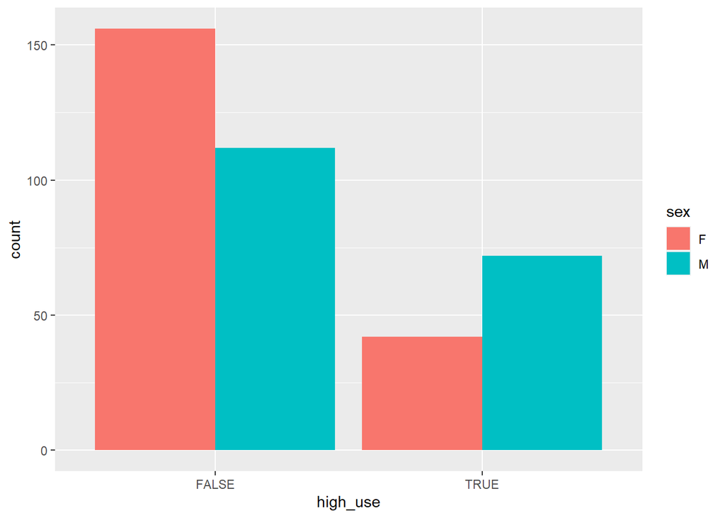

```r
pS <- ggplot(alc, aes(x = high_use, fill = sex))
pS + geom_bar(position = "dodge")
```

```r
xtabs(~ sex + high_use, data=alc)
```

```
##    high_use
## sex FALSE TRUE
##   F   156   42
##   M   112   72
```

```r
sexlog <- glm(high_use ~ sex, data = alc, family = "binomial")
summary(sexlog)
```

```
##
## Call:
## glm(formula = high_use ~ sex, family = "binomial", data = alc)
##
## Deviance Residuals:
##     Min       1Q   Median       3Q      Max
## -0.9964  -0.9964  -0.6905   1.3699   1.7610
##
## Coefficients:
##             Estimate Std. Error z value Pr(>|z|)
## (Intercept)  -1.3122     0.1738  -7.548 4.41e-14 ***
## sexM          0.8704     0.2303   3.779 0.000157 ***
## ---
## Signif. codes:  0 '***' 0.001 '**' 0.01 '*' 0.05 '.' 0.1 ' ' 1
##
## (Dispersion parameter for binomial family taken to be 1)
##
##     Null deviance: 465.68  on 381  degrees of freedom
## Residual deviance: 450.95  on 380  degrees of freedom
## AIC: 454.95
##
## Number of Fisher Scoring iterations: 4
```

#### 2.3.2 Final Grade and Alcohol Use

By plotting high_use with G3 we can get a graphic overview of high alcohol use and final grade. Here I use the `geom_boxplot` to visualise the results.

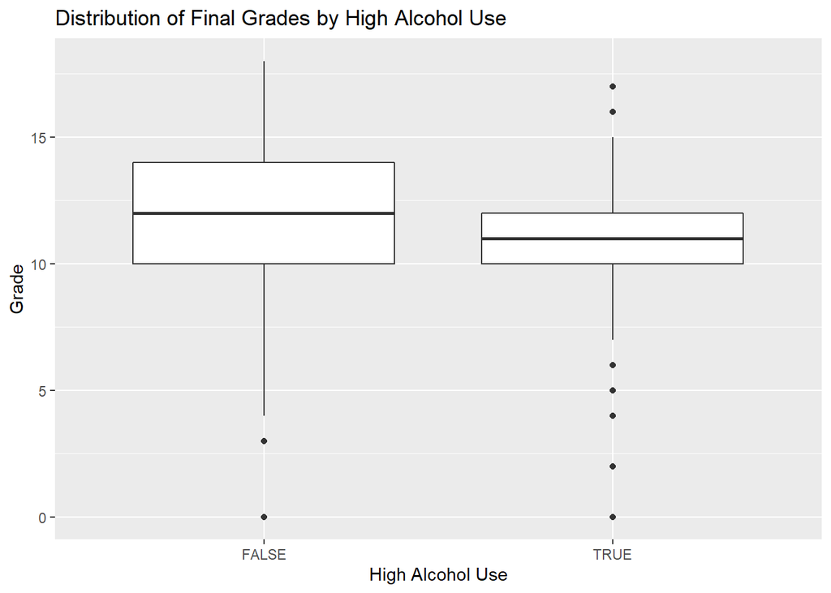

```r
pG3 <- ggplot(alc, aes(x = high_use, y = G3))
pG3 + geom_boxplot() + ggtitle("Distribution of Final Grades by High Alcohol Use") + labs(y = "Grade", x = "High Alcohol Use")
```

```r
G3log <- glm(high_use ~ G3, data = alc, family = "binomial")
summary(G3log)
```

```
##
## Call:
## glm(formula = high_use ~ G3, family = "binomial", data = alc)
##
## Deviance Residuals:
##     Min       1Q   Median       3Q      Max
## -1.2184  -0.8504  -0.7634   1.4307   1.7720
##
## Coefficients:
##             Estimate Std. Error z value Pr(>|z|)
## (Intercept)  0.09597    0.39319   0.244   0.8072
## G3          -0.08428    0.03389  -2.487   0.0129 *
## ---
## Signif. codes:  0 '***' 0.001 '**' 0.01 '*' 0.05 '.' 0.1 ' ' 1
##
## (Dispersion parameter for binomial family taken to be 1)
##
##     Null deviance: 465.68  on 381  degrees of freedom
## Residual deviance: 459.43  on 380  degrees of freedom
## AIC: 463.43
##
## Number of Fisher Scoring iterations: 4
```

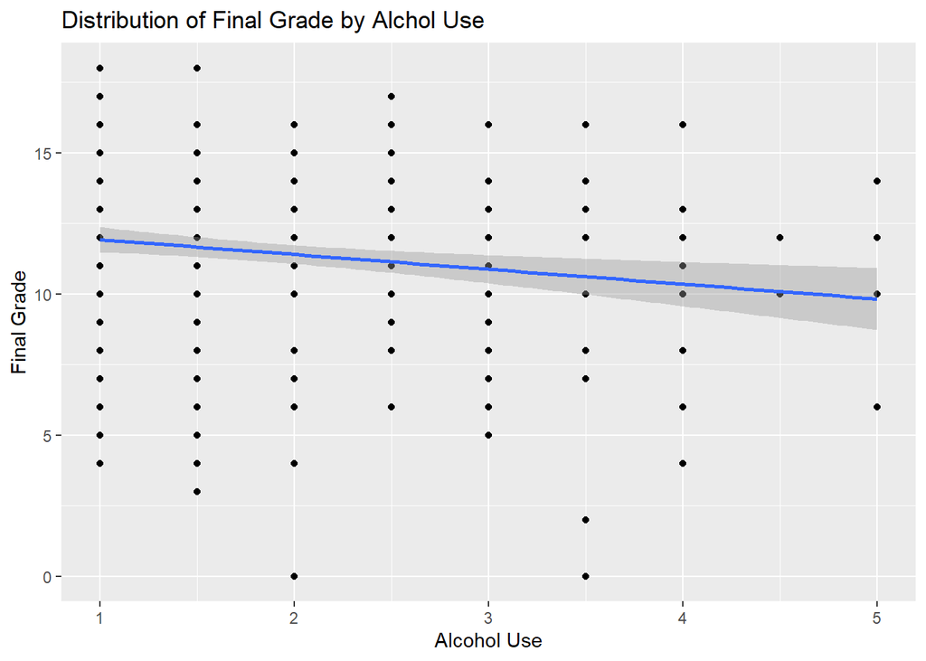

```r
pG3b <- ggplot(alc, aes(x = alc_use, y = G3))
pG3b + geom_point() + geom_smooth(method = "lm") + ggtitle("Distribution of Final Grade by Alchol Use") + labs(x = "Alcohol Use", y = "Final Grade")
```

#### 2.3.3 Family Relations and Alcohol Use

Make the same boxplot and `glm` for family relations:

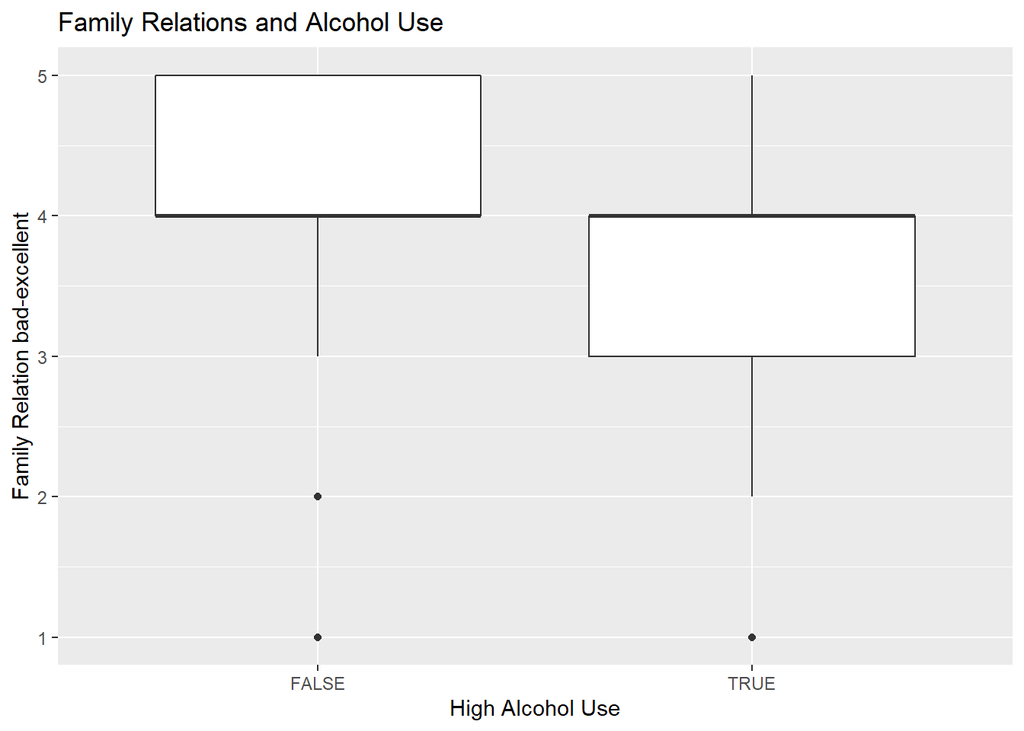

```r
pFR <- ggplot(alc, aes(x = high_use, y = famrel))
pFR + geom_boxplot() + ggtitle("Family Relations and Alcohol Use") + labs(y = "Family Relation bad-excellent", x = "High Alcohol Use")
```

```r
famlog <- glm(high_use ~ famrel, data = alc, family = "binomial")
summary(famlog)
```

```
##
## Call:
## glm(formula = high_use ~ famrel, family = "binomial", data = alc)
##
## Deviance Residuals:
##     Min       1Q   Median       3Q      Max
## -1.1404  -0.8323  -0.7427   1.4483   1.6869
##
## Coefficients:
##             Estimate Std. Error z value Pr(>|z|)
## (Intercept)   0.1772     0.4812   0.368   0.7127
## famrel       -0.2649     0.1212  -2.185   0.0289 *
## ---
## Signif. codes:  0 '***' 0.001 '**' 0.01 '*' 0.05 '.' 0.1 ' ' 1
##
## (Dispersion parameter for binomial family taken to be 1)
##
##     Null deviance: 465.68  on 381  degrees of freedom
## Residual deviance: 460.92  on 380  degrees of freedom
## AIC: 464.92
##
## Number of Fisher Scoring iterations: 4
```

The boxplot shows that High Alcohol Users have reported worse family relations and the `summary` for the glm shows statistical significance.

#### 2.3.4 Failures and Alcohol Use

This boxplot reveals that it was a silly idea to try to boxplot failures. A look at the count does reveal there might be something of interest, as the counts for failures are similar for non-high and high AU despite non-high AU outnumbering the high AU.

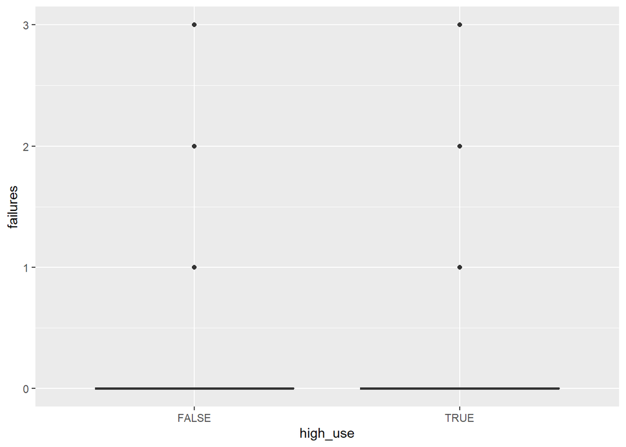

```r
pF <- ggplot(alc, aes(x = high_use, y = failures))
pF + geom_boxplot()
```

```r
silly <- alc %>% group_by(failures, high_use) %>% count()
silly
```

```
## # A tibble: 8 x 3
## # Groups:   failures, high_use [8]
##   failures high_use     n
##      <int> <lgl>    <int>
## 1        0 FALSE      244
## 2        0 TRUE        90
## 3        1 FALSE       12
## 4        1 TRUE        12
## 5        2 FALSE       10
## 6        2 TRUE         9
## 7        3 FALSE        2
## 8        3 TRUE         3
```

```r
failog <- glm(high_use ~ failures, data = alc, family = "binomial")
summary(failog)
```

```
##
## Call:
## glm(formula = high_use ~ failures, family = "binomial", data = alc)
##
## Deviance Residuals:
##     Min       1Q   Median       3Q      Max
## -1.4506  -0.7998  -0.7998   1.3703   1.6097
##
## Coefficients:
##             Estimate Std. Error z value Pr(>|z|)
## (Intercept)  -0.9756     0.1212   -8.05 8.28e-16 ***
## failures      0.5327     0.1812    2.94  0.00328 **
## ---
## Signif. codes:  0 '***' 0.001 '**' 0.01 '*' 0.05 '.' 0.1 ' ' 1
##
## (Dispersion parameter for binomial family taken to be 1)
##
##     Null deviance: 465.68  on 381  degrees of freedom
## Residual deviance: 456.98  on 380  degrees of freedom
## AIC: 460.98
##
## Number of Fisher Scoring iterations: 4
```

**Let’s try something else**. I change the failures column to a factor between student’s who have not failed (No) and students who have failed (Yes). This is done with the `ifelse` function that tests if the integer in numbers is 0, if yes then the student has not failed `yes = "No"` and vice versa. I tried to be funny at first and use “Nailed It” vs. “Failed It” but it looked ugly in the `summary`!

```r
alc$failures <- ifelse(test = alc$failures == 0, yes = "No", no = "Yes")
alc$failures <- as.factor(alc$failures)

xtabs(~ failures + high_use, data = alc)
```

```
##         high_use
## failures FALSE TRUE
##      No    244   90
##      Yes    24   24
```

```r
failog <- glm(high_use ~ failures, data = alc, family = "binomial")
summary(failog)
```

```
##
## Call:
## glm(formula = high_use ~ failures, family = "binomial", data = alc)
##
## Deviance Residuals:
##     Min       1Q   Median       3Q      Max
## -1.1774  -0.7924  -0.7924   1.1774   1.6195
##
## Coefficients:
##             Estimate Std. Error z value Pr(>|z|)
## (Intercept)  -0.9974     0.1233  -8.087 6.11e-16 ***
## failuresYes   0.9974     0.3139   3.177  0.00149 **
## ---
## Signif. codes:  0 '***' 0.001 '**' 0.01 '*' 0.05 '.' 0.1 ' ' 1
##
## (Dispersion parameter for binomial family taken to be 1)
##
##     Null deviance: 465.68  on 381  degrees of freedom
## Residual deviance: 455.80  on 380  degrees of freedom
## AIC: 459.8
##
## Number of Fisher Scoring iterations: 4
```

From this we see in the `xtabs` that the odds for failing when high_use is TRUE is higher. We also get a slightly better result (do we?) for the `glm` `summary`.

## 3 Logistic Regression

In this section I make a `glm` model of `high_use` predicted by `failures` (Yes/No),`G3` `famrel`, and `sex`.

```r
m <- glm(high_use ~ failures + G3 + famrel + sex, data = alc, family = "binomial")


summary(m)
```

```
##
## Call:
## glm(formula = high_use ~ failures + G3 + famrel + sex, family = "binomial",
##     data = alc)
##
## Deviance Residuals:
##     Min       1Q   Median       3Q      Max
## -1.5508  -0.8521  -0.6323   1.2056   2.0863
##
## Coefficients:
##             Estimate Std. Error z value Pr(>|z|)
## (Intercept)  0.25806    0.67429   0.383 0.701929
## failuresYes  0.72633    0.35352   2.055 0.039922 *
## G3          -0.05299    0.03816  -1.389 0.164947
## famrel      -0.28260    0.12637  -2.236 0.025337 *
## sexM         0.92053    0.23750   3.876 0.000106 ***
## ---
## Signif. codes:  0 '***' 0.001 '**' 0.01 '*' 0.05 '.' 0.1 ' ' 1
##
## (Dispersion parameter for binomial family taken to be 1)
##
##     Null deviance: 465.68  on 381  degrees of freedom
## Residual deviance: 434.75  on 377  degrees of freedom
## AIC: 444.75
##
## Number of Fisher Scoring iterations: 4
```

Out of the four variables used to predict high AU, the final grade G3 conditional on the other explanatory variables performs the worst in the model and the low z value and high p-value suggest it is better to leave it out of the model, which is done in section 3.2.

### 3.1 Odds Ratio and Confidence Interval

To get odds ratios we can apply the exponent function `exp` to the coefficients of the model and assign the output as `OR`. For confidence intervals use the `exp` and `confint` functions on the model.

```r
OR <- coef(m) %>% exp

CI <- confint(m) %>% exp
cbind(OR, CI)
```

```
##                    OR     2.5 %    97.5 %
## (Intercept) 1.2944226 0.3434018 4.8737594
## failuresYes 2.0674839 1.0298765 4.1416381
## G3          0.9483869 0.8794608 1.0217987
## famrel      0.7538209 0.5873863 0.9658242
## sexM        2.5106222 1.5841230 4.0260443
```

What these mean. The exponents of the coefficients can be interpreted as odd ratios (**OR**) for High AU between a unit change (vs no change) in the explanatory variable. The CI output is showing several 95% intervals. It is two-tailed, from the 2.5% point to the 97.5% point of the relevant distribution. These form the upper and lower limits of the intervals. The factor variables sex and failures show width in their distribution.

### 3.2 New Model

For a new model I repeat the steps in the previous section, but omit G3 as an explanatory variable.

```r
m1 <- glm(high_use ~ failures + sex + famrel, data = alc, family = "binomial")

summary(m1)
```

```
##
## Call:
## glm(formula = high_use ~ failures + sex + famrel, family = "binomial",
##     data = alc)
##
## Deviance Residuals:
##     Min       1Q   Median       3Q      Max
## -1.5802  -0.8370  -0.6357   1.1834   1.9682
##
## Coefficients:
##             Estimate Std. Error z value Pr(>|z|)
## (Intercept)  -0.3570     0.5085  -0.702 0.482576
## failuresYes   0.9247     0.3233   2.860 0.004234 **
## sexM          0.9125     0.2368   3.854 0.000116 ***
## famrel       -0.2848     0.1260  -2.260 0.023829 *
## ---
## Signif. codes:  0 '***' 0.001 '**' 0.01 '*' 0.05 '.' 0.1 ' ' 1
##
## (Dispersion parameter for binomial family taken to be 1)
##
##     Null deviance: 465.68  on 381  degrees of freedom
## Residual deviance: 436.69  on 378  degrees of freedom
## AIC: 444.69
##
## Number of Fisher Scoring iterations: 4
```

```r
OR1 <- coef(m1) %>% exp


CI1 <- confint(m1) %>% exp
cbind(OR1, CI1)
```

```
##                   OR1     2.5 %    97.5 %
## (Intercept) 0.6997429 0.2549556 1.8868349
## failuresYes 2.5210180 1.3345773 4.7672023
## sexM        2.4905835 1.5736004 3.9879379
## famrel      0.7521293 0.5863812 0.9629022
```

```r
########################
# anova(m, m1, test ="LRT")
########################
```

The model performs better, but there is a low difference in the Null Deviance and Residual Deviance. This spells trouble. A look at how the model predicts reveals some of its problems in the next section.

### 3.3 Prediction

For prediction based on the model we need to create a value for probabilities with the `predict` function used on the m1 model. A column is created for probability that contains the values of the probabilities created. A second new column is created for probabilities over 0.5, which estimates the high alcohol use to be TRUE.

```r
# predict() the probability of high_use
probabilities <- predict(m1, type = "response")

# add the predicted probabilities to 'alc'
alc <- mutate(alc, probability = probabilities)

# use the probabilities to make a prediction of high_use
alc <- mutate(alc, prediction = probability > 0.5)

# tabulate the target variable versus the predictions
table(high_use = alc$high_use, prediction = alc$prediction)
```

```
##         prediction
## high_use FALSE TRUE
##    FALSE   255   13
##    TRUE     97   17
```

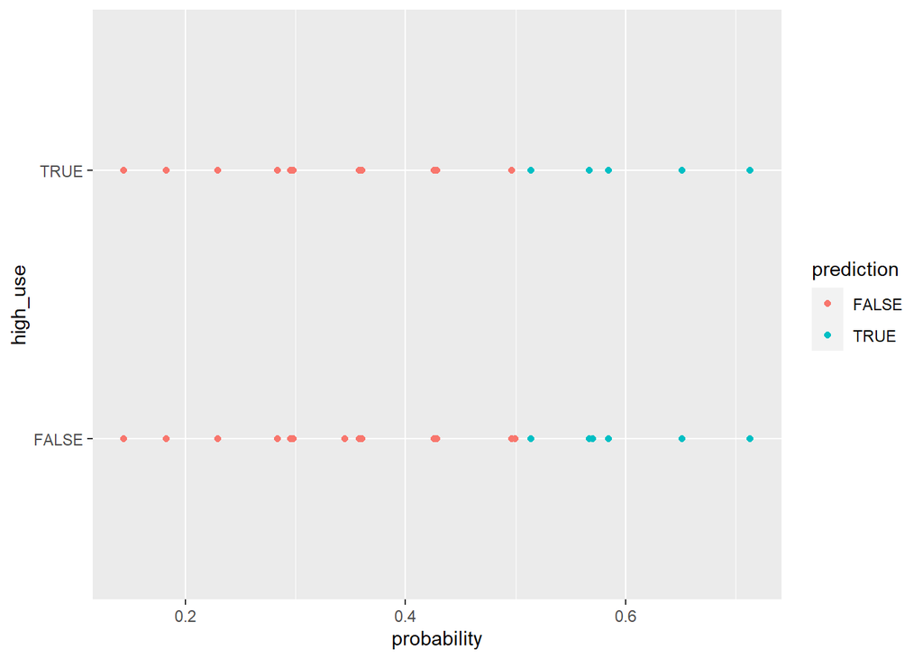

```r
g <- ggplot(alc, aes(x = probability, y = high_use, col = prediction))

# define the geom as points and draw the plot
g + geom_point()
```

```r
table(high_use = alc$high_use, prediction = alc$prediction) %>% prop.table %>% addmargins
```

```
##         prediction
## high_use      FALSE       TRUE        Sum
##    FALSE 0.66753927 0.03403141 0.70157068
##    TRUE  0.25392670 0.04450262 0.29842932
##    Sum   0.92146597 0.07853403 1.00000000
```

```r
alc <- alc %>% mutate(TEST = case_when(
  high_use == FALSE & prediction == FALSE ~ "YAY",
  high_use == TRUE & prediction == TRUE ~ "SWEET",
  high_use == FALSE & prediction == TRUE ~ "NAY",
  high_use == TRUE & prediction == FALSE ~ "DAMN"))

test_count <- alc %>% count(TEST)
print(test_count)
```

```
##    TEST   n
## 1  DAMN  97
## 2   NAY  13
## 3 SWEET  17
## 4   YAY 255
```

### 3.4 Prediction Error

Prediction error for the new model can be tested by creating a new function, though I do not entirely understand what is happening in it. The function contains two arguments class and prob on which it counts the mean of n_wrong. n_wrong is defined as `abs(class - prob) > 0.5` but what exactly that means is a mystery to me.

```r
# define a loss function (average prediction error)
loss_func <- function(class, prob) {
  n_wrong <- abs(class - prob) > 0.5
  mean(n_wrong)
}

# call loss_func to compute the average number of wrong predictions in the (training) data
loss_func(class = alc$high_use, prob = alc$probability)
```

```
## [1] 0.2879581
```

The output gives the average number of wrong predictions as 0.29. While it may seem kind of decent, we have to remember how miserably the prediction worked for predicting TRUE High Use. So if we wanted to use this model for something, it would be okay at predicting non-high alcohol use (and as such, it could create a “risk group” for high alcohol use) but ultimately it is insufficient in predicting High Alcohol Use.